# Baltimore Analysis

Maggie Kane

## **Baltimore, Smalltimore**

# *Can a correlation be made between location, race, and wealth in the city of Baltimore? Propose reasons why these patterns may exist.*

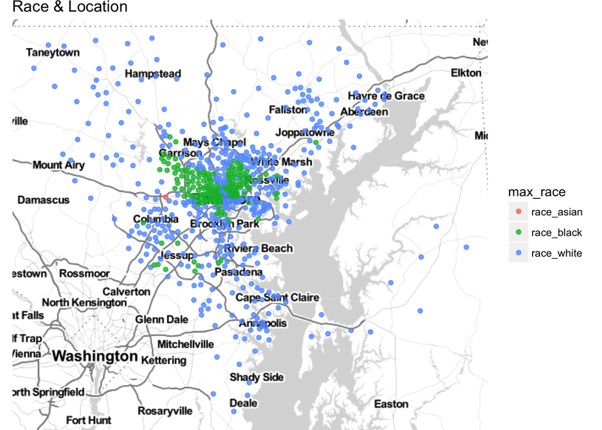

A majority of white Baltimoreans seem to be settled just about everywhere except for the east and west sides of inner Baltimore City. If you have ever seen the HBO show, The Wire, you can see that the east and west side of Baltimore City are known as the most dangerous parts of the state of Maryland. In 2018, USA Today named Baltimore City the most dangerous city in the US (Madhani, 2018). This high ranking is due to a significant amount of gang activity and homicides within the inner city. In the figure above, you can see a direct correlation between these inner city areas and the most prominent race. As depicted in the HBO series, Baltimore city is populated by a majority of black families. Although there are many other races scattered throughout the city, this graph is simply showing the most prominent race in each neighborhood. After filtering through much of the census data, it is apparent that many of the graphs formed this sort of splitting pattern within the city. A similar relationship is shown below with respect to people who were born in the state of Maryland.

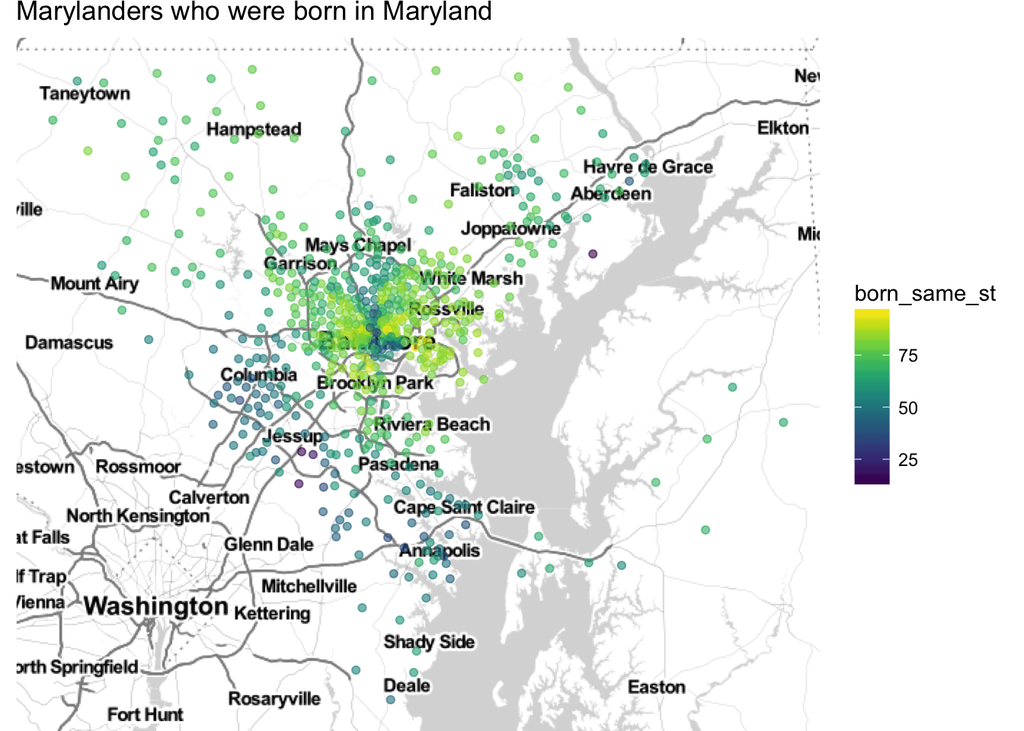

The second figure here further depicts how a majority of people who live in Baltimore City were born in Maryland as well. Many people who were born in Maryland choose to stay in Baltimore because of their ‘Maryland pride’. Although Marylanders love to wave their iconic flag around and gloat about their delicious crabcakes, the census data analysis shows that there could be other reasons why so many Marylanders stay in the same state.

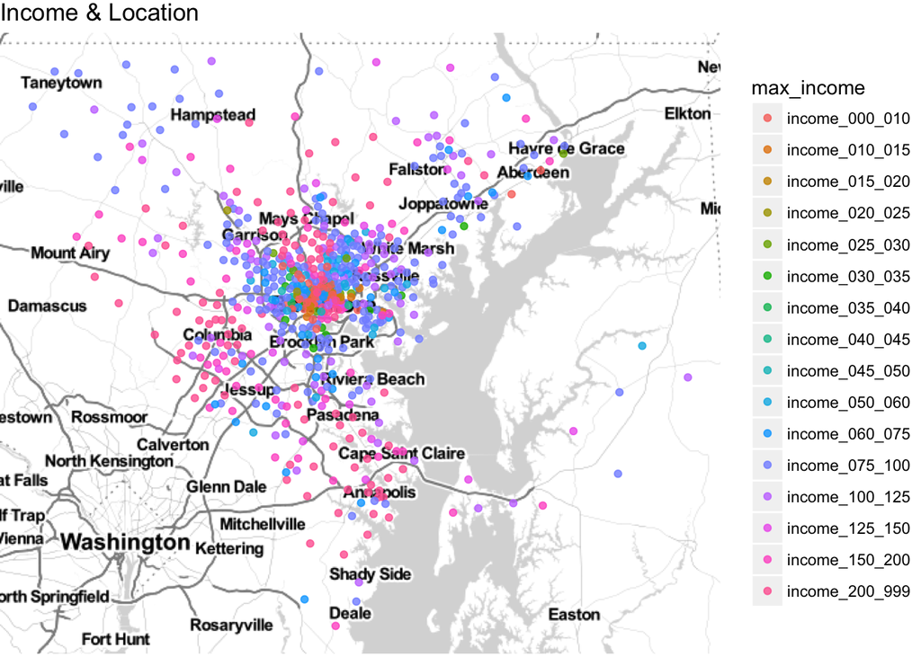

In conclusion, the census data of Baltimore has highlighted the relationship that exists between race, location, and income of Baltimore citizens. While many people assume that Marylanders choose to stay in Maryland for their pride, this data has suggested another reason. Many people could come to the conclusion that income levels are so low within the inner city that many Baltimoreans do not have the opportunity to leave the state of Maryland. This can then go further to explain the city’s violence and homicide tendencies. Even though mortality rates were not recorded within this census data, one can even predict that there must be a correlation between race, location, income, and mortality rates within Baltimore neighborhoods. It would be interesting to see if an increase in income level would lead towards more neighborhood diversity and decreased violence.

## References

Madhani, Aamer. “Baltimore is the nations most dangerous city.” USA Today, Gannett Satellite Information Network, 19 Feb. 2018, www.usatoday.com/story/news/2018/02/19/homicides-toll-big-u-s-cities-2017/302763002/.